# CMDA4654_Project1

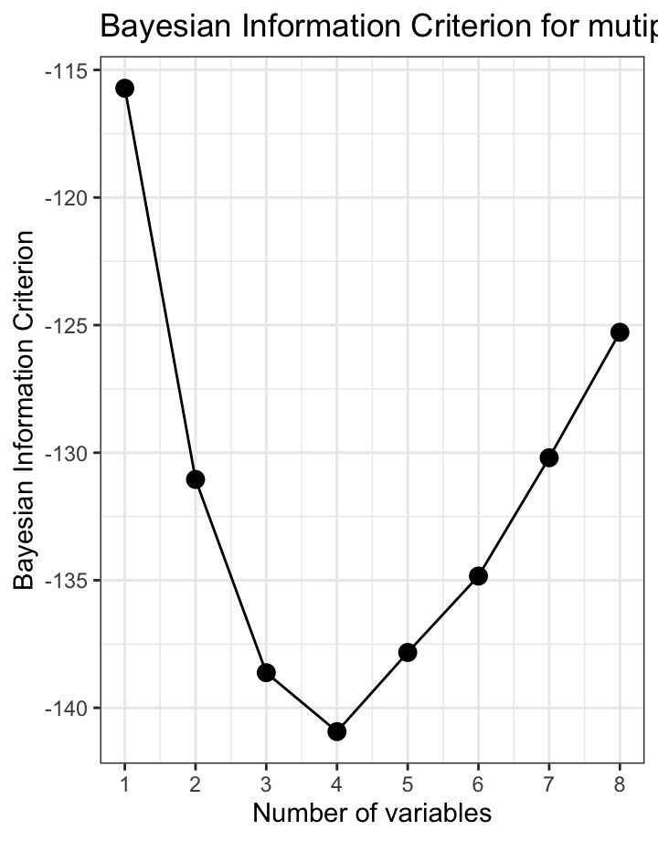

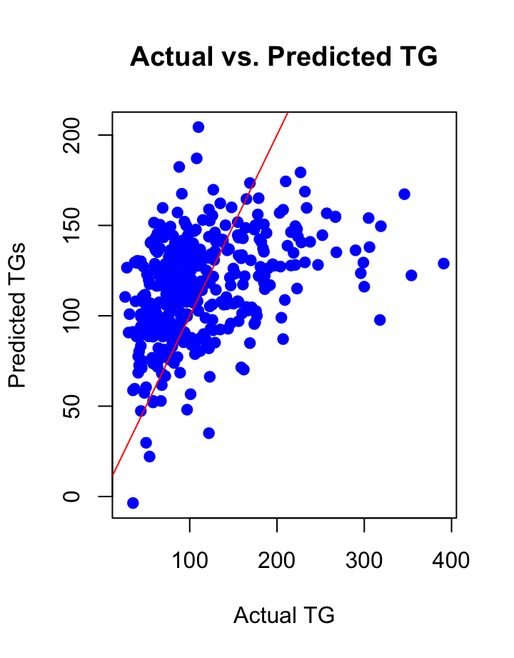

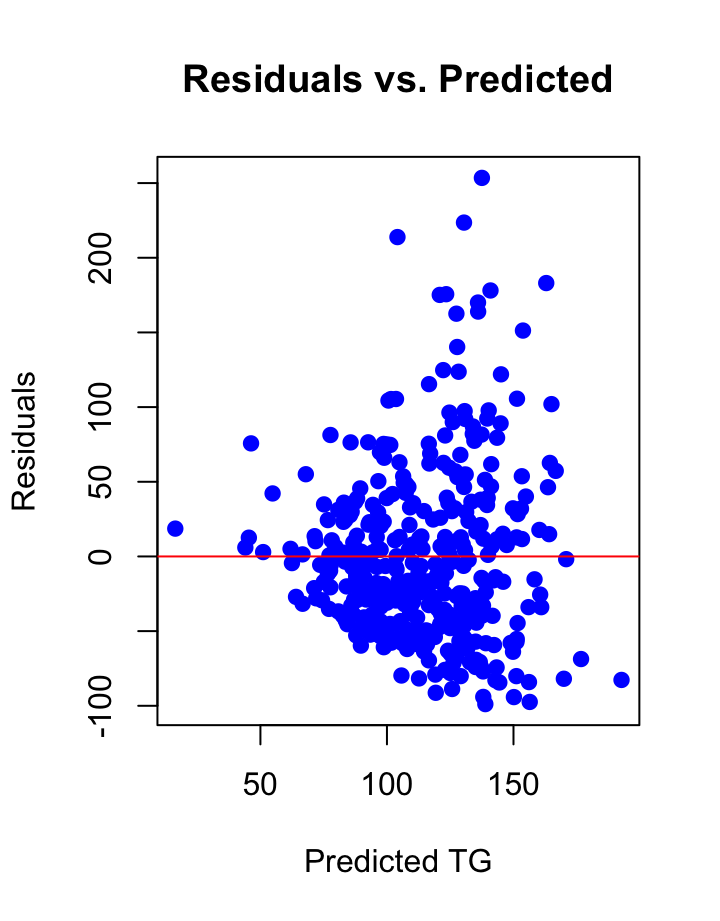

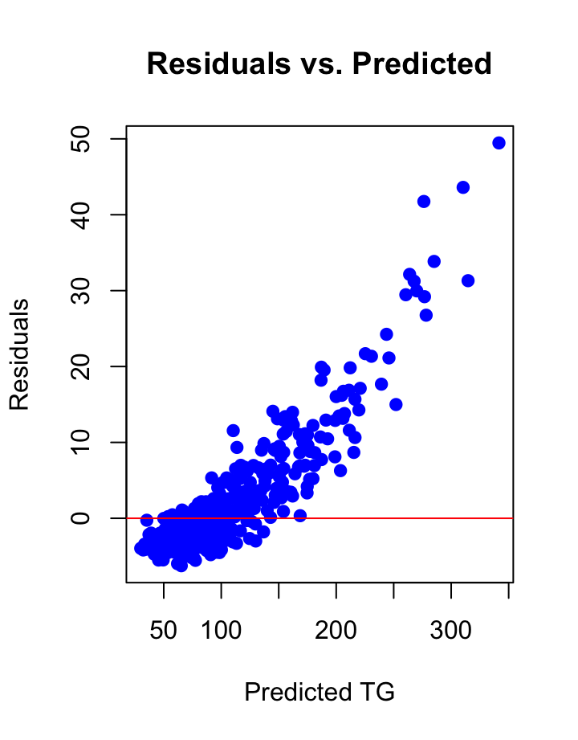

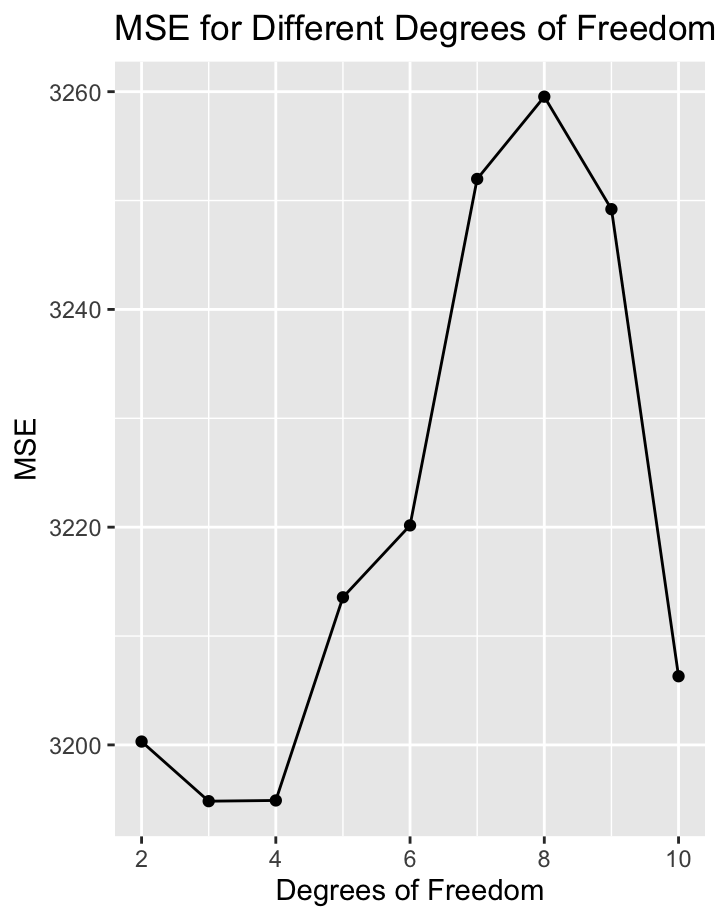

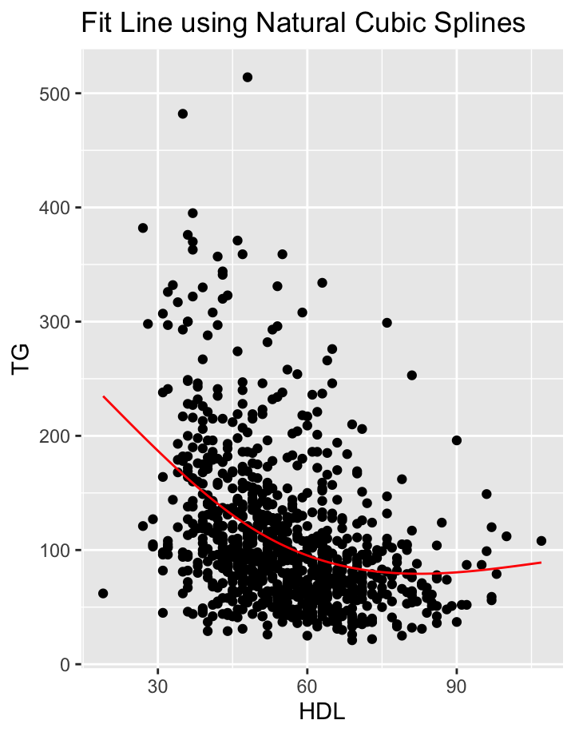

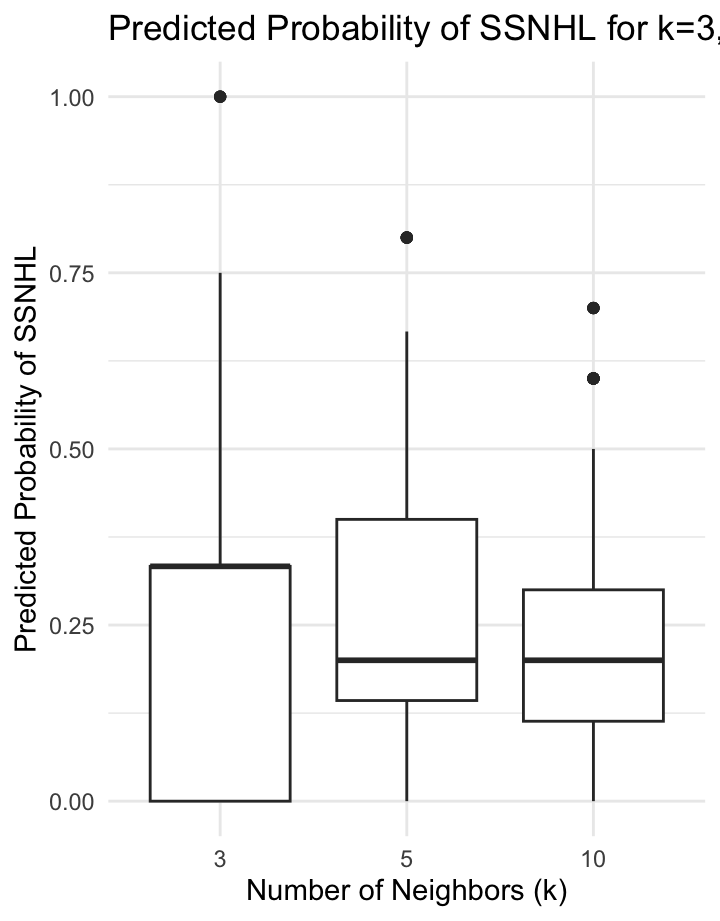

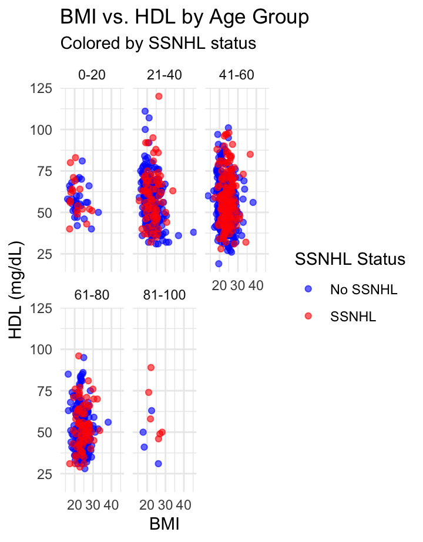

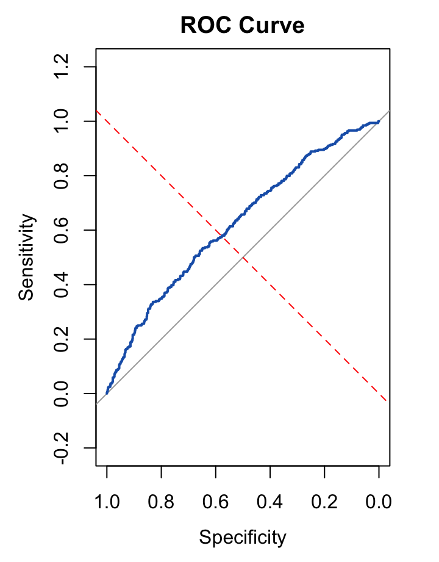

# Dataset information

### Dataset information

data_of_control_972.xlsx: contain data for individual who doesn’t have sudden sensorineural hearing loss

SSNHL_PLOS.xlsx: contain data for individual who have sudden sensorineural hearing loss

Website: https://zenodo.org/records/5010818

Drive: https://drive.google.com/drive/folders/1UsqUvodLMr_k93TVjaSuRARqlXIyLe3e?usp=drive_link

In this study, we retain only the data that are consistent across both datasets and features whose meanings are unequivocally clear.

### Raw data’s feature

| Feature | Description |
| --- | --- |
| sudden | Sudden Sensorineural Hearing Loss happen |
| ID | A unique identifier for each individual |
| sex | The biological sex |
| age | The age of the individual |
| hypertension | This individual has hypertension |
| dyslipidemia | This individual has dyslipidemia, which is an abnormal amount of lipids in the blood |
| stroke | This individual has stroke |
| MI/angina | This individual has Myocardial infarction |
| Diabetes | This individual has diabetes. |
| Thyroid | This individual has thyroid dysfunction |
| CRF | This individual has Chronic Renal Failure |
| Height | The height of the individual, in centimeters |
| Weight | The weight of the individual, in kilograms |
| BMI | Body Mass Index of the individual |
| HE_wc | Waist circumference, possibly measured at the health examination in unit of centimeters |
| TOTALchole | Total cholesterol levels in the blood |
| HDL | High-Density Lipoprotein cholesterol levels |
| TG | Triglycerides |
| LDLcal | Low-Density Lipoprotein cholesterol |
| Phospholipid | Phospholipid levels in the blood. |
| Free Fatty Acid | Free fatty acid levels in the blood. |
| Lipoprotein | Likely indicates the concentration of a certain lipoprotein subclass. |
| Lipid_total | Total lipid levels in the blood. |
| Followup_weeks | The number of weeks of follow-up after an initial event or diagnosis. |
| Siegel_criteria | Likely a scoring or classification system related to the study, perhaps to grade the severity of hearing loss. |
| Initial_audio(dB) | The level of hearing loss at first diagnosis. |
| Last_audio(dB) | The current level of hearing loss. |
| AUDIORt | An audio test result for the right ear |
| AUDIOLt | An audio test result for the left ear |

### Cleaned feature used in this report

| Feature | Description |
| --- | --- |
| sudden | Sudden Sensorineural Hearing Loss happen |
| sex | The biological sex |
| age | The age of the individual |
| hypertension | This individual have hypertension |
| dyslipidemia | This individual have dyslipidemia, which is an abnormal amount of lipids in the blood. |
| stroke | This individual have stroke. |
| MI_angina | This individual have Myocardial infarction |
| Diabetes | This individual have diabetes. |
| Thyroid | This individual have thyroid dysfunction |
| CRF | This individual have Chronic Renal Failure |
| Height | The height of the individual, in centimeters. |
| Weight | The weight of the individual, in kilograms. |
| BMI | Body Mass Index of the individual. |
| HDL | High-Density Lipoprotein cholesterol levels |
| TG | Triglycerides |
| LDLcal | Low-Density Lipoprotein cholesterol |

# Multiple Regression

### TG Prediction Using Multiple Regression

Multiple regression allows us to use data from various columns to predict `TG` levels, which are typically measured through a blood test. If a reliable regression model is developed, it can save costs associated with additional testing. Our analysis using best subset regression suggests that a model with four variables (`age`, `CRF`, `Weight`, `HDL`) has the lowest BIC value and a relatively high adjusted $R^2$. However, visual inspection of the model’s predictions compared to actual `TG` levels indicates the model may not be ideal for this dataset. Moreover, the regression line’s jagged appearance in the TG vs. HDL graph may suggest overfitting.

### Find Best Subset Regression Evaluation

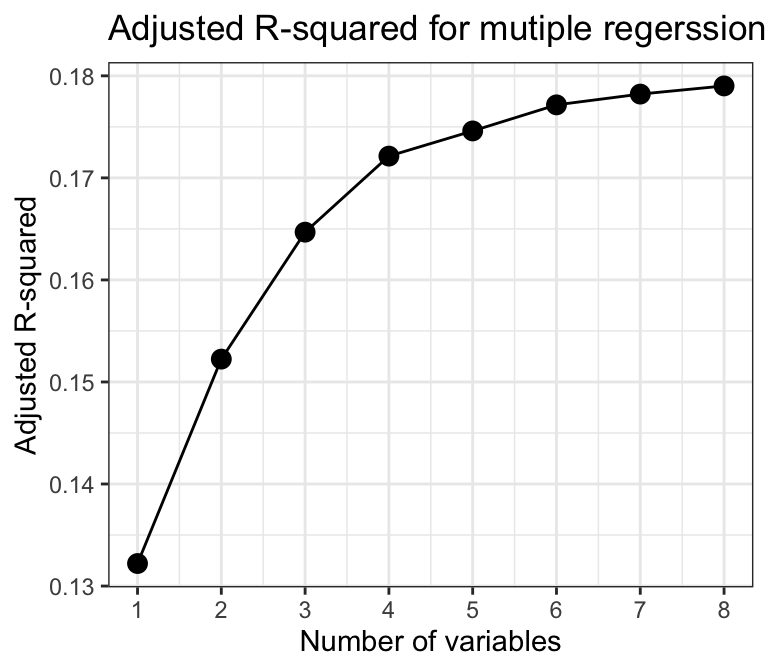

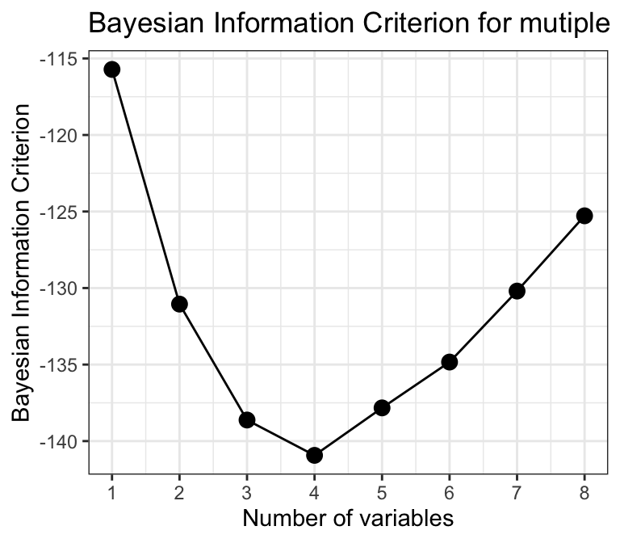

### Multiple Regression Model for TG

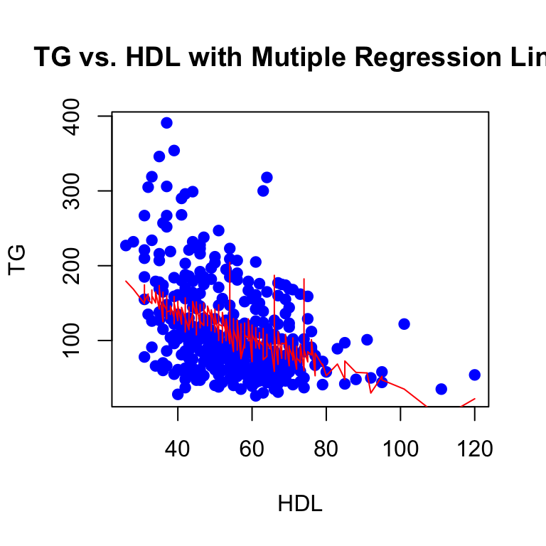

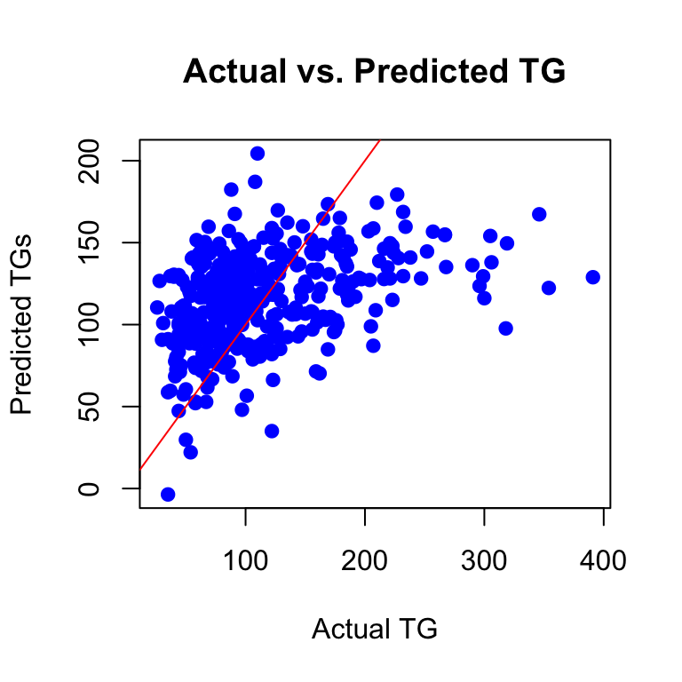

Coefficients of the Multiple Regression Model for TG

|  | Estimate | Std. Error | t value | Pr(>\|t\|) |
| --- | --- | --- | --- | --- |
| (Intercept) | 121.622 | 17.627 | 6.900 | 0.000 |
| age | 0.499 | 0.139 | 3.588 | 0.000 |
| CRF | 93.973 | 31.132 | 3.019 | 0.003 |
| Weight | 0.890 | 0.180 | 4.945 | 0.000 |
| HDL | -1.615 | 0.154 | -10.498 | 0.000 |

# Ridge Regression

### Predict TG Using Ridge Regression & Log Transformation

In this algorithm, the magnitude of the coefficients derived from the Ridge Regression Model suggests a significant association between “TG” and the variables “CRF,” “dyslipidemia,” and “Thyroid,” as evidenced by their relatively large coefficients.

Upon examining the fitted regression line, evidence of heteroscedasticity was observed, characterized by non-constant variance in the residuals of the predicted values. To address this, a logarithmic transformation was applied, significantly improving the model’s fit. This improvement is quantitatively supported by the reduction in the Mean Squared Error (MSE), which decreased from 3248.609 to 72.087, underscoring the effectiveness of the logarithmic transformation.

### Ridge Regression: using all feature to predict TG

Coefficients of the Ridge Regression Model for TG

| Term | Coefficient |
| --- | --- |
| (Intercept) | 138.745 |
| sudden | 13.721 |
| sex | -8.458 |
| age | 0.274 |
| hypertension | 5.976 |
| dyslipidemia | 22.123 |
| stroke | 8.175 |
| MI_angina | 5.920 |
| Diabetes | 8.316 |
| Thyroid | -21.576 |
| CRF | 60.607 |
| Height | -0.073 |
| Weight | 0.316 |
| BMI | 1.449 |
| HDL | -1.259 |
| LDLcal | -0.044 |

### Ridge Regression: using all feature to predict TG

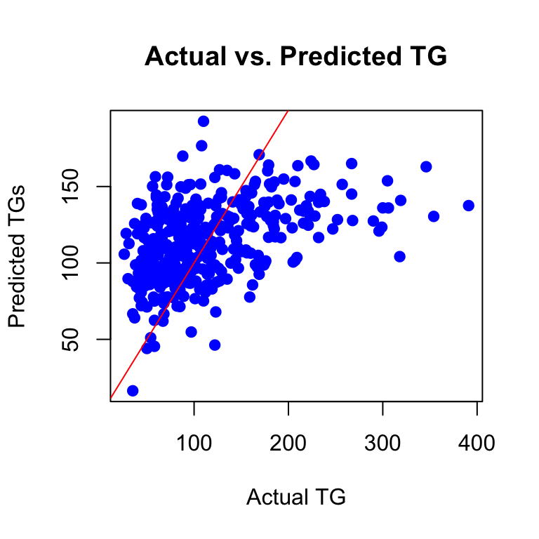

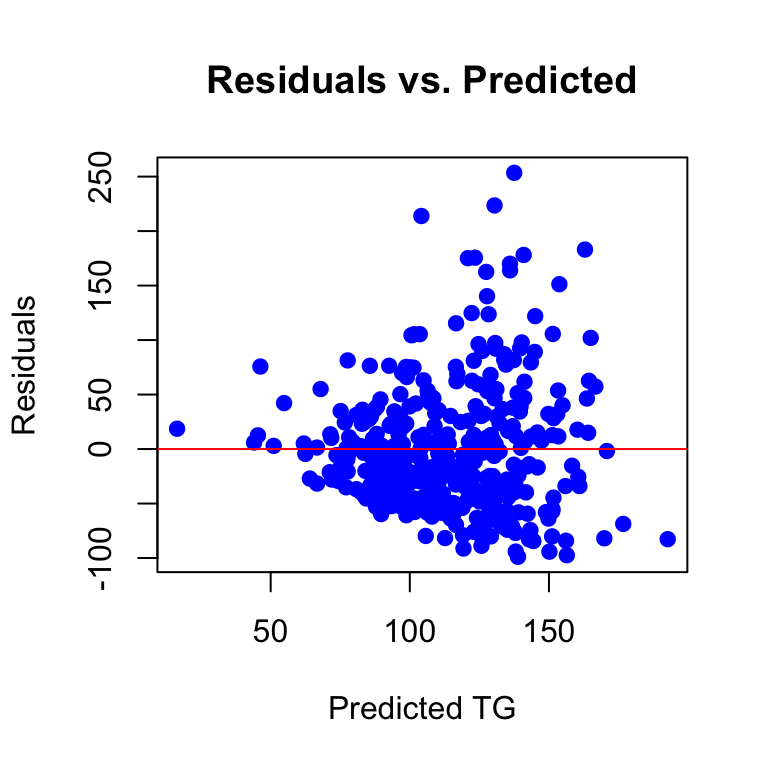

Evaluation Value for Ridge Regression

| Metric | Value |
| --- | --- |
| MSE | 3248.609 |
| R2 | 0.182 |
| Adjusted_R2 | 0.149 |

### Ridge Regression: Log Tranformation on TG

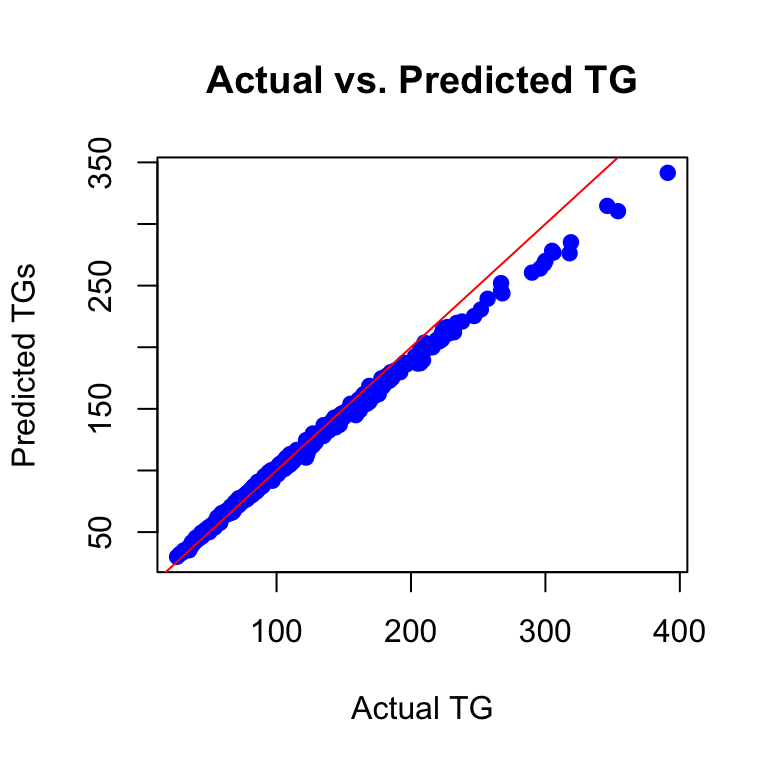

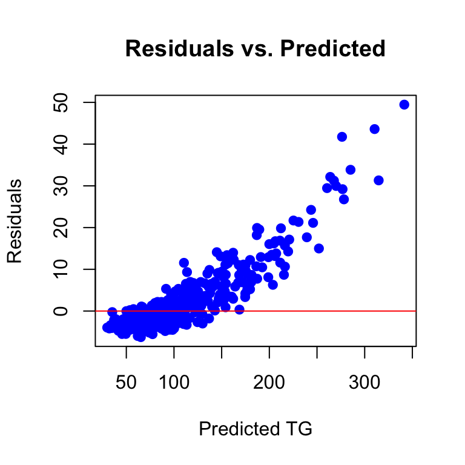

Evaluation Value for Ridge Regression After Log Transformation

| Metric | Value |
| --- | --- |
| MSE | 72.087 |
| R2 | 0.982 |
| Adjusted_R2 | 0.981 |

# natural cubic spline

### Natural Cubic Spline to Predict TG Using HDL

For the natural cubic spline analysis, we initially evaluated the optimal degree of freedom by examining the “MSE for Different Degrees of Freedom” graph. This progress shown that a natural cubic spline with three degrees of freedom (df=3) is the optimal selection based on the lowest mean squared error.

After fitting the data with a natural cubic spline of df=3, the resulting fit line appeared to be well-balanced, demonstrating a smooth curve without signs of overfitting. However, the model exhibited a relatively high mean squared error (MSE) and a low coefficient of determination ($R^2$) for both in-sample and out-of-sample data. This outcome could be attributed to the dispersed nature of the data, suggesting that the relationship between the variables may not be readily observable.

### Scatter Plot for TG vs. HDL & Degree of Freedom Test.

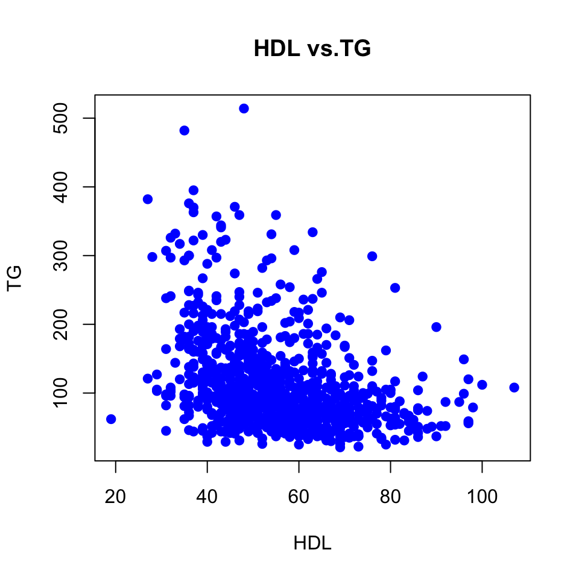

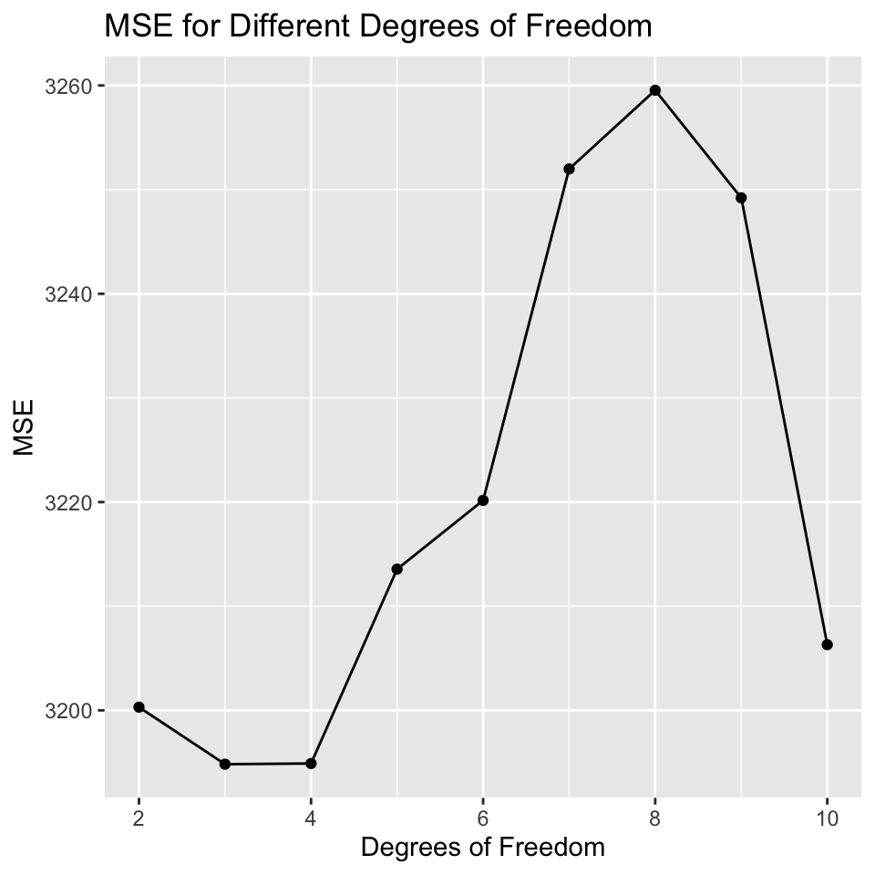

### Scatter Plot With Natural Cubic Spline

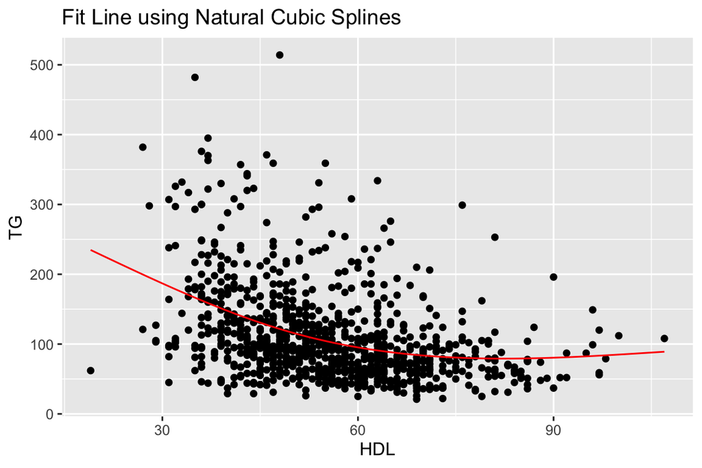

Evaluation Value for Natural Cubic Spline

| Metric | Value |
| --- | --- |
| in sample MSE | 3892.0849 |
| in sample R2 | 0.1586 |
| out of sample MSE | 3194.8315 |
| out of sample R2 | 0.1956 |

# kNN classifiication

Introduction

This study utilizes k-Nearest Neighbors (kNN) classification to investigate whether common health indicators—Body Mass Index (BMI), high-density lipoprotein (HDL), and triglycerides (TG)—can predict the risk of sudden sensorineural hearing loss (SSNHL). Through machine learning, we aim to determine the significance of these indicators in relation to SSNHL, optimizing our kNN model by testing various neighbor values. Our goal is to provide insights into potential early warning signs for SSNHL, which could be instrumental in guiding preventive measures.

### kNN classifiication

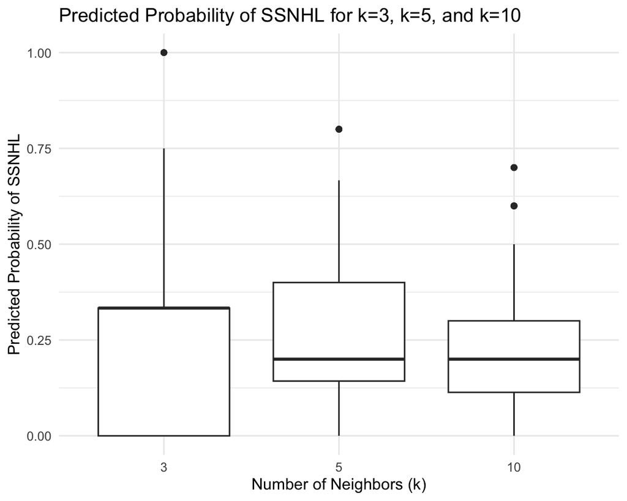

kNN Table

KNN Classification Results for Different Values of k

| k | True_Negatives | False_Positives | False_Negatives | True_Positives |
| --- | --- | --- | --- | --- |
| 3 | 158 | 57 | 35 | 8 |
| 5 | 163 | 57 | 30 | 8 |
| 10 | 180 | 60 | 13 | 5 |

# Naive Bayes Classification

Introduction

Ｗe’re using Naive Bayes classification to sift through data on SSNHL, HDL, and BMI. This statistical approach will allow us to categorize each person into different risk levels for sudden hearing loss based on these health indicators. By analyzing the patterns in this data, Naive Bayes helps us identify who is at a higher risk. This insight is vital for early intervention, where we can offer specific guidance or treatment to those identified as high-risk, aiming to reduce their chances of experiencing sudden hearing loss.

Conclusion

Naive Bayes Classification

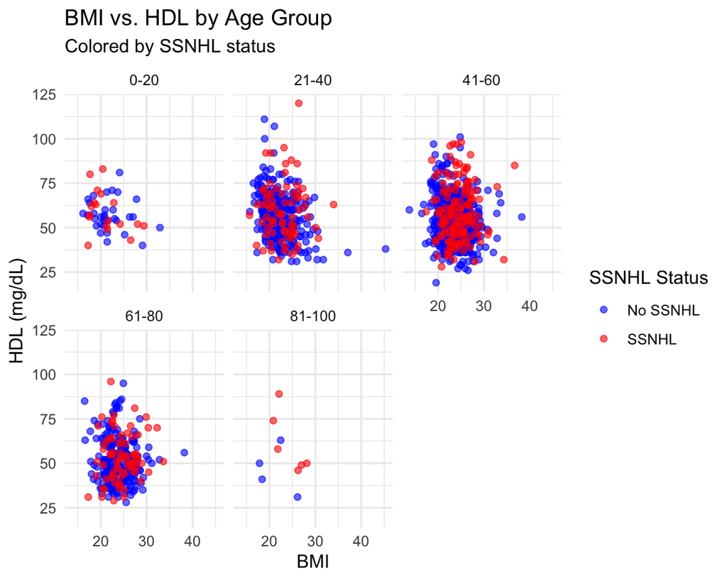

Bayes Table

Performance Metrics

| Performance Metrics Metric | Performance Metrics Value |
| --- | --- |
| Accuracy | 0.7209302 |
| Precision | 0.7320000 |
| Recall | 0.9734043 |
| F1 Score | 0.8356164 |

# Classification using Logistic Regression

Introduction

Classification using Logistic Regression

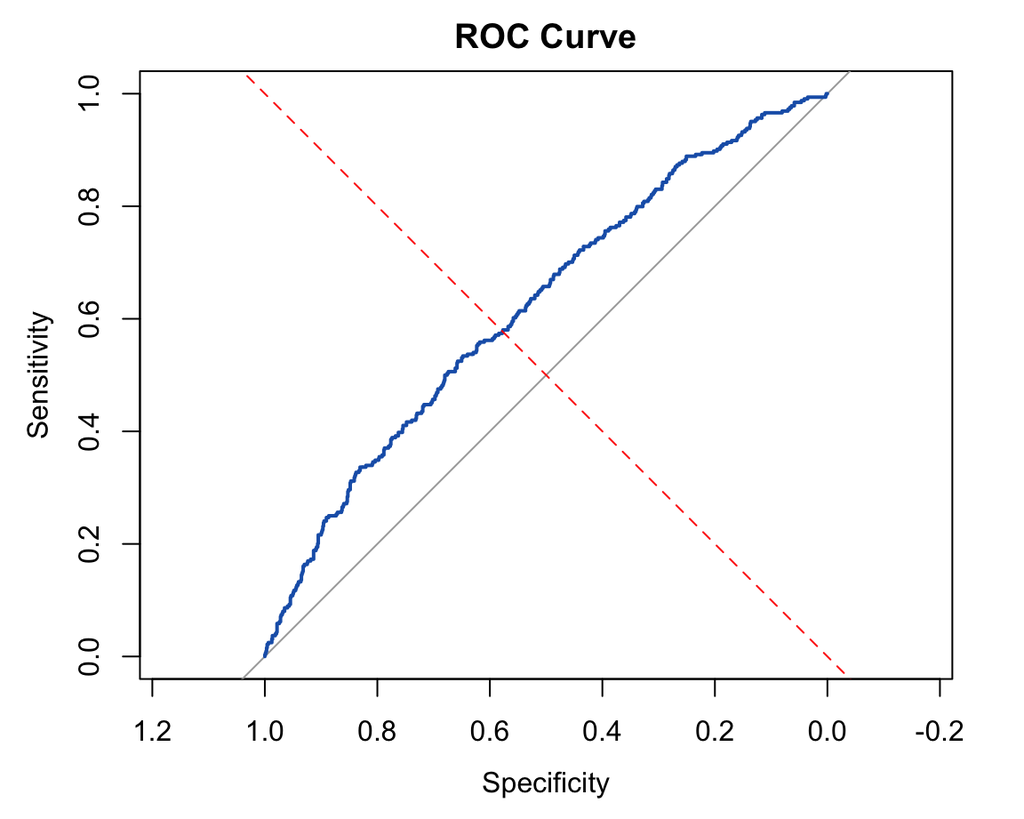

Logistic Regression Table

Logistic Regression Classification Confusion Matrix

|  | Actual Class 0 | Actual Class 1 |
| --- | --- | --- |
| 0 | 962 | 316 |
| 1 | 7 | 8 |

Logistic Regression Performance Metrics

| Performance Metrics Accuracy | Performance Metrics Precision | Performance Metrics Recall | Performance Metrics F1.Score |
| --- | --- | --- | --- |
| 0.75 | 0.53 | 0.02 | 0.05 |